# DAGs

Manoel Galdino

04/10/2021

# Introdução a DAGs

DAGs ou Directed Acyclic Graphs, também conhecidos como Diagramas Causais, são uma abordagem de inferência causal que surgiu no começo do séc. XX, mas que se desenvolveu e se tornou um programa de pesquisa fecundo após o trabalho de Judea Pearl e colegas. Um DAG, como o nome diz, é um gráfico direcionado e acíclico. Isso significa que não há causalidade reversa ou causalidade simultânea.

# Um exemplo de DAG

# Notação de DAGs

# Tipos de DAGs

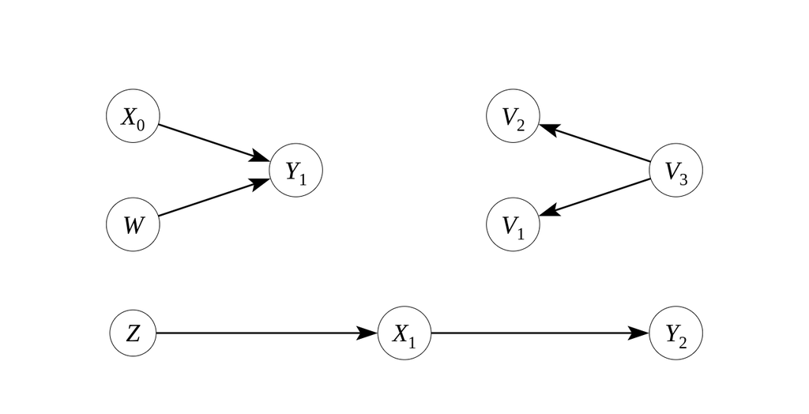

# Correlação e causalidade

– “Correlação não implica causalidade”

– Associação estatística (como correlação) na população (amostra infinita) decorre de três relações estruturais

– 1. Relação de causa e efeito (chains)

– 2. Existência de causas comuns (forks)

– 3. Ajustar (controlar, condicionar) para efeitos compartilhados (collider ou selection bias)

– Em amostras finitas, pode ocorrer por acaso/aleatoriedade

# O que um DAG significa?

- Todas as flechas especificam qual a relação de causalidade entre as variáveis
- Ausência de flecha significa que não há relação causal entre variáveis
- O DAG estabelece relações na população, isto é, não diz respeito a questões estatísticas de amostras finitas
- O DAG deve representar o modelo causal do pesquisador ou de uma teoria
- Causalidade como intervenção: se eu mudar o valor de x independentemente do que causa x, o que acontece com y?
- Causalidade representada por P(Y|Do(X = x1)) - P(Y|Do(X = x0)), isto é, qual a probabilidade de y se eu mudar x de x0 para x1?

# Causalidade como intervenção

Considere o DAG abaixo:

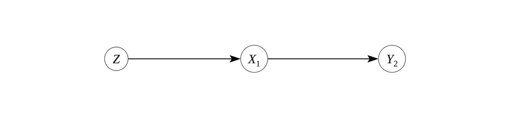

Z causa $X_{1}$ e $X_{1}$ causa $Y_{2}$. Digamos que eu esteja interessado em saber o efeito causal se X = 2.

Então, faço uma invervenção “cirúrgica”, em que removo as causas de X, e faço X valer exatamente 2, e aí observo como Y muda. Esse é o efeito causal de X = 2 no DAG. Graficamente, representamos a cirurgia com a remoção de todos os ancestrais de X.

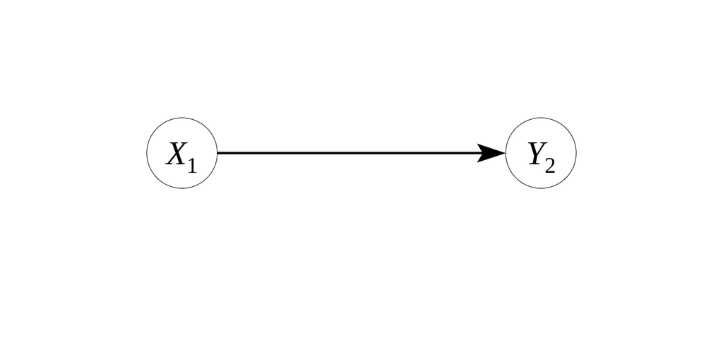

# Variáveis em um DAG

– preditor/VI/ exposure/tratamento: X, a variável de interesse que deve ser a causa do efeito.

– resposta/VD: Y, a variável que é o efeito ou o resultado do tratamento/preditor.

# Variáveis em um DAG - continuação

# D-separação

O processo de determinar, dado um DAG e um conjunto de variáveis condicionantes (“controles”), se um par de variáveis é estatisticamente independente ou dependente.

A Ideia é associar dependência com conexão, isto é, se existe um caminho (não bloqueado) entre duas variáveis, e associar d-separação com ausência de conexão ou caminho (livre).

# D-separação - Regra 1 - Separação não-condicional

X e Y estão d-conectados se existe um caminho (não-bloqueado) entre eles.

Um caminho é qualquer sequência consecutiva de arestas (independentemente da direção).

Um caminho não-bloqueado é um caminho que pode ser traçado sem passar por um colisor (collider). Em outras palavras, flechas que apontam para um collider não constituem um caminho que passe informação.

# D-separação - Regra 1 - Separação não-condicional (continuação)

- No DAG 1 ao lado, X e Y são d-conectados, pois eles se conectam por um caminho não bloqueado.
- No DAG 2 ao lado, X e Y não estão d-conectados, pois a única a conexão é por um caminho bloqueado por W, um collider.
- No DAG 3 ao lado, X e Y estão d-conectados.

DAG 1

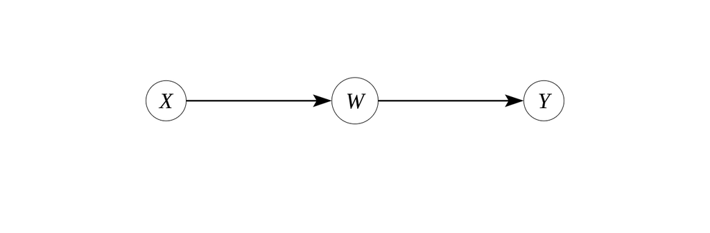

DAG 2

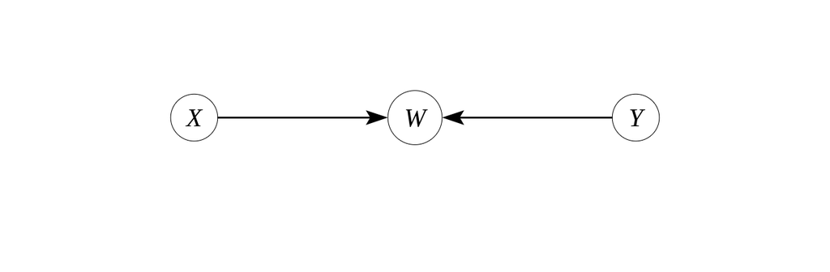

DAG 3

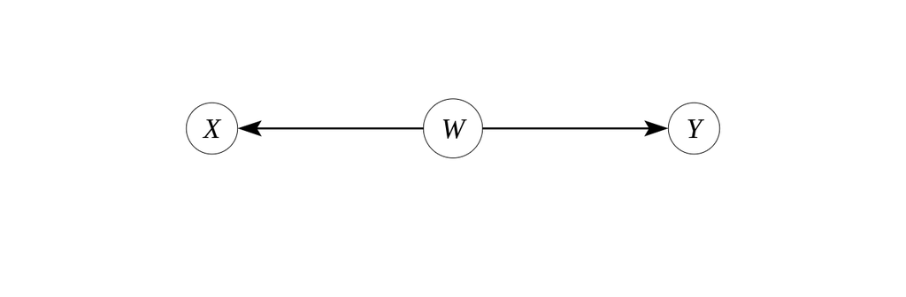

# D-separação - Regra 2 - Bloqueio por condicionamento (“controle”)

Se medirmos um conjunto de variáveis Z, e tomarmos seus valores como dados, isso pode mudar a relação estatística entre as demais variáveis do DAG.

Regra 2: se x e y estão d-conectados, condicional a um conjunto de variáveis Z, se há um caminho livre de colliders entre X a Y sem passar por nenhuma variável de Z.

Se um caminho desses não existe, dizemos que X e Y são d-separados por Z, ou que cada caminho entre X e Y é bloqueado por Z. Exemplo: Z = {R,V}

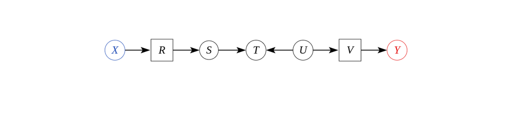

Exercício: Precisamos mesmo condicionar em R e V para bloquear o caminho entre X e Y? Se Não, qual o conjunto mínimo de variáveis necessárias para bloquear o caminho?

# 3. Condicionar em um collider

Medir um efeito comum de duas causas independentes cria uma associação entre elas. É o paradoxo de Berkson. Exemplo: Você vai no DCE e pergunta quantas pessoas são canhotas. E vai no encontro anual de canhotos e perguntas quantos são de esquerda. Junta as duas amostrar e procura ver se há correlação entre ser canhoto e ser de esquerda. E deve encontrar uma correlação negativa entre as variáveis.

Regra 3: Se um collider ou seu descendente é membro de Z, ele desbloqueia o caminho.

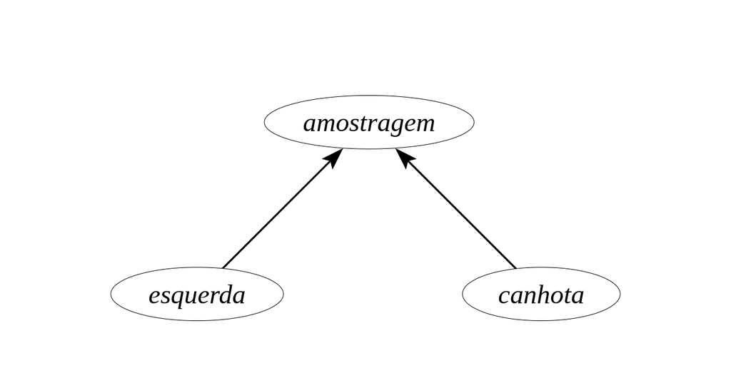

# 3. Condicionar em um collider

Vamos fazer uma simulação?

```r
library(ggplot2)
library(tidyverse)

set.seed(2) # tornando o exemplo reproduzível
x <- rnorm(1000)
w <- rnorm(1000)
y <- 2*x + 2*w + rnorm(1000)
summary(y)
```

```
##    Min. 1st Qu.  Median    Mean 3rd Qu.    Max.
## -9.9472 -1.7974  0.3005  0.2322  2.2123  9.4704
```

```r
# condicionando em y > 0
df <- data.frame(x = x, w=w, y = y) %>%
  filter(y > 0)

cor.test(x, w, method=c("pearson", "kendall", "spearman"))
```

```
##
##  Pearson's product-moment correlation
##
## data:  x and w
## t = 1.0602, df = 998, p-value = 0.2893
## alternative hypothesis: true correlation is not equal to 0
## 95 percent confidence interval:
##  -0.02851241  0.09533482
## sample estimates:
##        cor
## 0.03353996
```

```r
cor.test(df$x, df$w, method=c("pearson", "kendall", "spearman"))
```

```
##
##  Pearson's product-moment correlation
##
## data:  df$x and df$w
## t = -9.1222, df = 530, p-value < 2.2e-16
## alternative hypothesis: true correlation is not equal to 0
## 95 percent confidence interval:
##  -0.4396192 -0.2925266
## sample estimates:
##        cor
## -0.3683761
```

```r
# condicionar em descedente de collider também causa problema, ainda que mais atenuado
g <- .5*y + rnorm(1000)

df1 <- data.frame(x = x, w=w, y = y, g = g) %>%
  filter(g > 0)

cor.test(df1$x, df1$w, method=c("pearson", "kendall", "spearman"))
```

```
##
##  Pearson's product-moment correlation
##
## data:  df1$x and df1$w
## t = -4.7704, df = 535, p-value = 2.375e-06
## alternative hypothesis: true correlation is not equal to 0
## 95 percent confidence interval:
##  -0.2817877 -0.1194185
## sample estimates:
##        cor
## -0.2019907
```

Notem que a correlação estimada é menor, isto é, um pouco mais próxima de zero. O tamanho do viés depende da relação entre variáveis.

# Backdoor criterion

Ou seja, se eu “controlar” (condicionar) para variáveis Z1, Z2, .. Zn na minha regressão, vou conseguir estimar o efeito causal de X sobre Y, desde que X não cause Z1, Z2, …, Zn, e se os controles bloqueiam os caminhos de variáveis de confusão.

# Identificação causal

– O que significa identificação causal ou um modelo ser identificado?

– Com uma amostra infinita (sem incerteza amostral), é possível estimar o parâmetro (efeito causal) de uma variável

– Podemos falar também em identificação parcial

– Quando é possível impor limites (intervalo), mas não estimativa pontual.

– Estratégia de identificação é como a teoria e o desenho de pesquisa produzem suposições plausíveis de que o modelo é identificado

# estratégias de identificação

Vocês vão ver no curso várias estratégias de identificação. Vou passar rapidamente por duas delas, utilizando DAGS

# Controlar para uma variável

Essa é a técnica de regressão usual.

Podemos aplicar a definição para verificar.

# Variáveis Instrumentais

Exemplo: AJR The Colonial Origins of Comparative Development: An Empirical Investigation

Instituiçoes inclusivas que causam desenvolvimento?

# Próximos passos

– Desenhe o DAG em cada pesquisa causal que você se envolver

– Desenhe o DAG de cada paper causal que você ler

– Desenhe o DAG de cada paper causal que você vir em um seminário

– Pergunte-se: Há algum backdoor aberto?

– Há algum collider que estão controlando e não deviam?

– Em geral, o backdoor vem de variável defasada no tempo. Inclua uma no DAG.

# Obrigado

Contato: mgaldino@transparencia.org.br

Twitter: @mgaldino